# R4Photobiology Start-up Guide

# Filters & lamps

**1: Filters**

Package **photobiologyFilters** is a collection of spectral transmittance data for more than **300 filters** measured in our lab, by collaborators or for which data have been made available by the suppliers for inclusion in this package.

A list of the available spectra:

```
##   [1] "Baader_U_filter"
##   [2] "BPI_Luminance"
##   [3] "BPI_Solatrol"
##   [4] "BW_007_Clear_MRC_nano"
##   [5] "Courtaulds_CA_115um"
##   [6] "Courtaulds_CA_115um_age000"
##   [7] "Courtaulds_CA_115um_age020"
##   [8] "Courtaulds_CA_115um_age030"
##   [9] "Courtaulds_CA_115um_age060"
##  [10] "Courtaulds_CA_115um_age100"
##  [11] "Courtaulds_CA_115um_age180"
##  [12] "Courtaulds_CA_115um_age300"
##  [13] "Courtaulds_CA_250um"
##  [14] "Courtaulds_CA_480um"
##  [15] "Evonik_Cherry_3C01_GT"
```

[output cut: 324 more lines]

Filters can be accessed based on specific criteria

```r
all_filter_accessors
```

```
##  [1] "acetate_filters"            "acrylic_filters"
##  [3] "baader_filters"             "band_pass_filters"
##  [5] "blue_filters"               "blue_green_filters"
##  [7] "bpi_visqueen_filters"       "bw_filters"
##  [9] "clear_filters"              "courtaulds_filters"
## [11] "etola_filters"              "evonik_filters"
## [13] "fake_unbranded_filters"     "firecrest_filters"
## [15] "foiltek_filters"            "fotga_filters"
## [17] "green_filters"              "haida_filters"
## [19] "heat_filters"               "heliopan_filters"
## [21] "hoya_filters"               "kenko_filters"
## [23] "kolarivision_filters"       "lee_filters"
## [25] "long_pass_filters"          "mcdermit_filters"
## [27] "midopt_filters"             "neutral_filters"
## [29] "old_schott_filters"         "optical_glass_filters"
## [31] "orange_filters"             "photography_filters"
## [33] "plastic_film_filters"       "plastic_sheet_filters"
## [35] "plexiglas_filters"          "polycarbonate_filters"
## [37] "polyester_filters"          "polystyrene_filters"
## [39] "polyvynil_chloride_filters" "red_nir_filters"
## [41] "rocolax_filters"            "rosco_filters"
## [43] "schott_filters"             "short_pass_filters"
## [45] "tiffen_filters"             "uqg_filters"
## [47] "uv_filters"                 "uvir_cut_filters"
## [49] "uvroptics_filters"          "xl_horticulture_filters"
## [51] "yellow_filters"             "zeiss_filters"
## [53] "zomei_filters"
```

For example, all filters made of polyesters:

```r
polyester_filters
```

```
## [1] "Foiltek_Clear_PET_G"             "McDermit_PET_Autostat_CT5_125um"
```

We can plot each filter, or multiple ones:

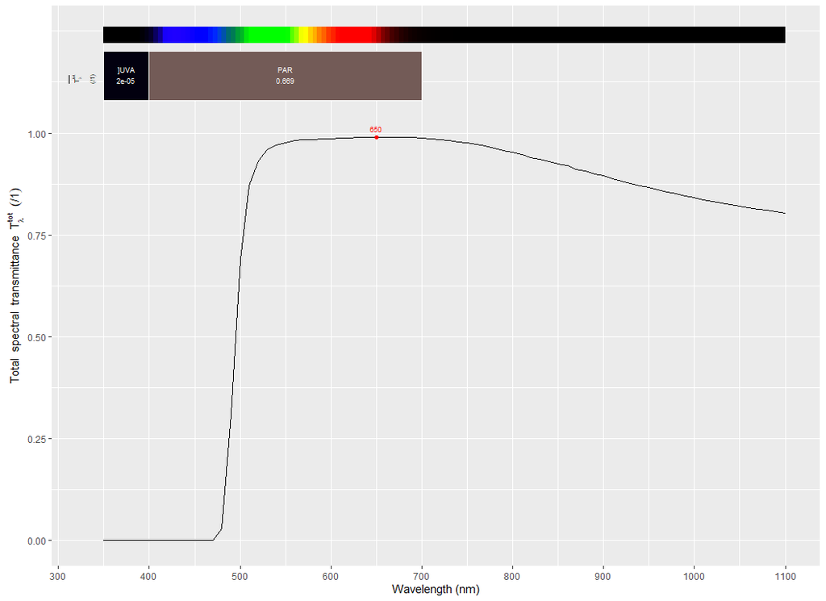

```r
autoplot(filters.mspct$MIDOPT_LP500)
```

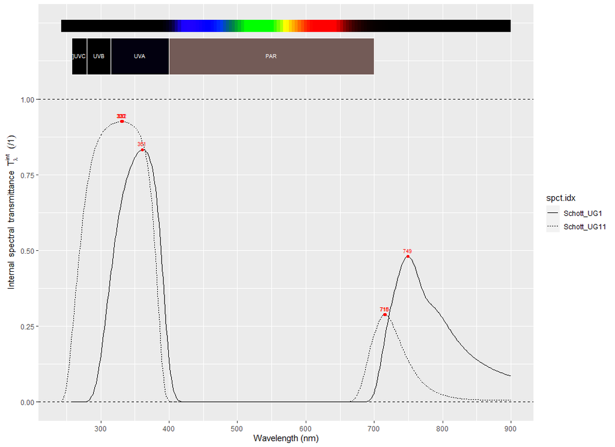

```r
autoplot(filters.mspct[c("Schott_UG1", "Schott_UG11")],
         range = c(200, 900),
         annotations = c("+", "boundaries"),
         span = 11)
```

In the same way as for the spectral weighing function, we can apply a filter to a spectum:

```r
autoplot(sun.spct)
```

[output not shown]